# W5 Exercise - Graphs

Author

Xingyu Hu

1. How can you improve the following graph?

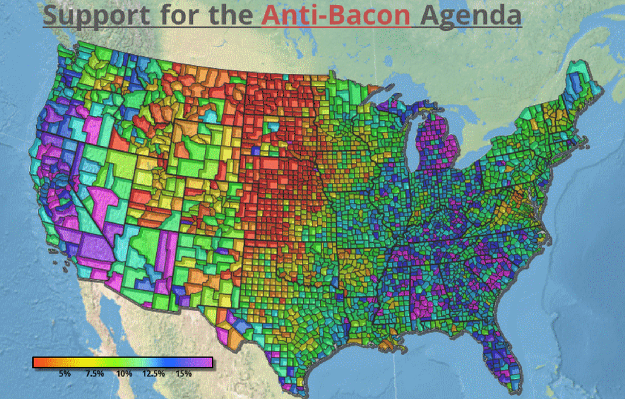

- Enlarge scale bar font size;
- Discard background map;
2. Criticize the following graphs:
   1. [Mykland et al. (1995)](https://www.jstor.org/stable/2291148) Regeneration in Markov chain samplers. Journal of the American Statistical Association 90:233-241, Figure 1

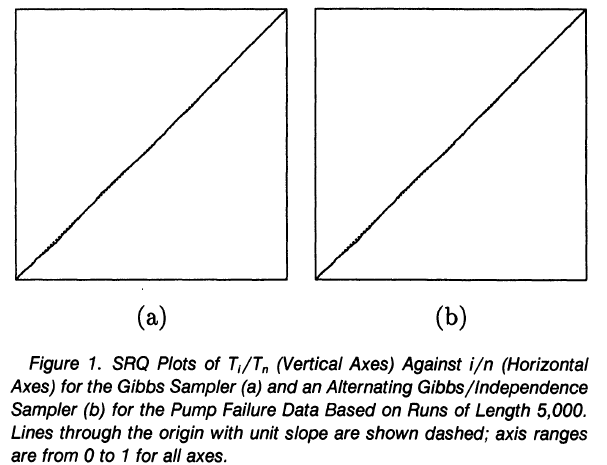

   - No labels or ticks for x and y-axis;
   2. [Hummer et al. (2001)](https://www.ncbi.nlm.nih.gov/pmc/articles/PMC115017/) Role for p53 in gene induction by double-stranded RNA. J Virol 75:7774-7777, Figure 4

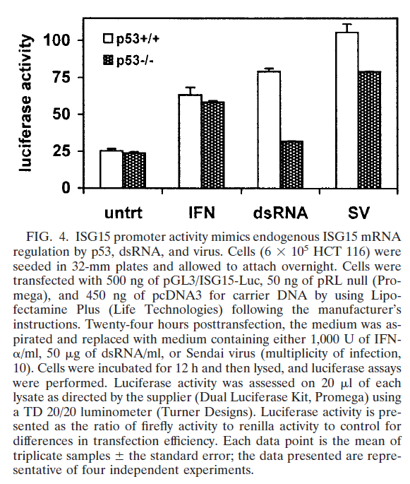

   - No minus error bar;
   - y axis should have `%` sign;
   3. [Cawley et al. (2004)](https://www.sciencedirect.com/science/article/pii/S0092867404001278?via%3Dihub) Unbiased mapping of transcription factor binding sites along human chromosomes 21 and 22 points to widespread regulation of noncoding RNAs. Cell 116:499-509, Figure 1

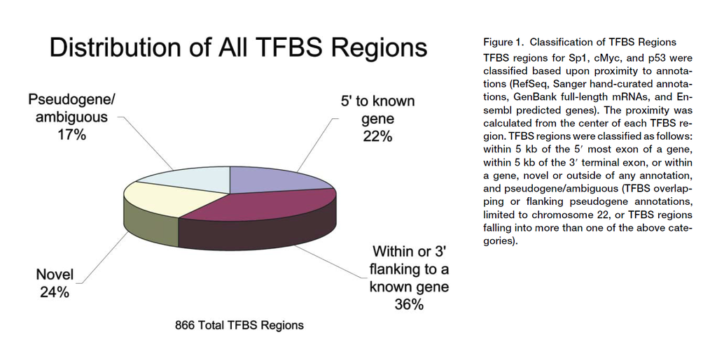

   - No 3D pie chart;
   4. [Jorgenson et al. (2005)](https://www.ncbi.nlm.nih.gov/pmc/articles/PMC1196373/) Ethnicity and human genetic linkage maps. American Journal of Human Genetics 76:276-290, Figure 2

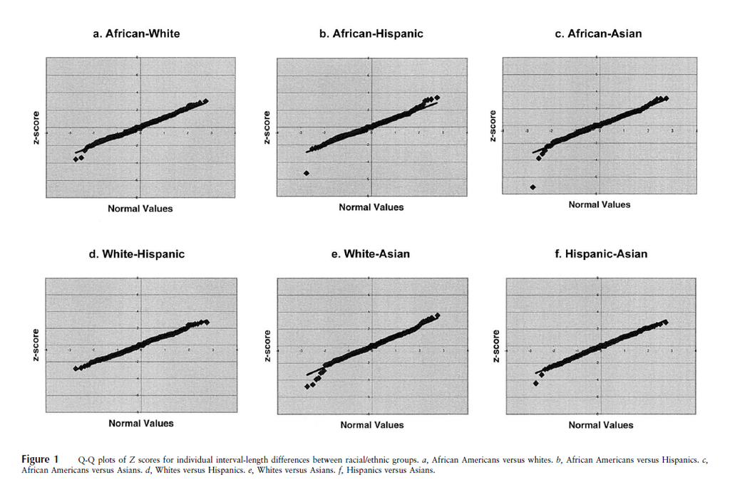

   - Background color is not suitable;
   - Axis ticks font size is too small
3. In an aerosol particle size distribution figure, the x-axis label is $D_p(\mu m)$, and the y-axis label is $\frac{\mathrm{d}N}{\mathrm{d}\log D_p}(\mathrm{cm}^{-3})$:

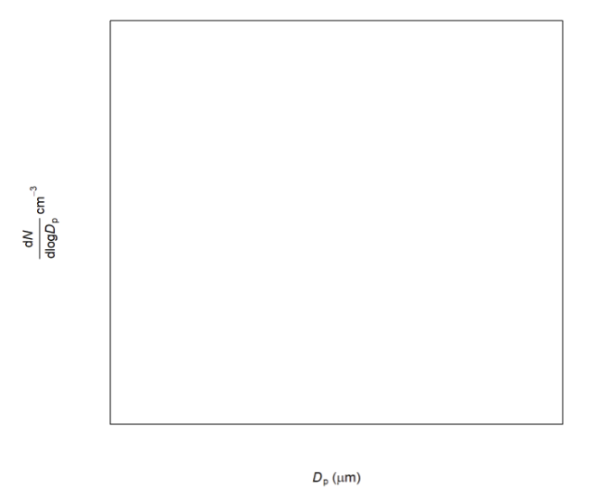

Write the R code for inserting the axis labels into a graph.

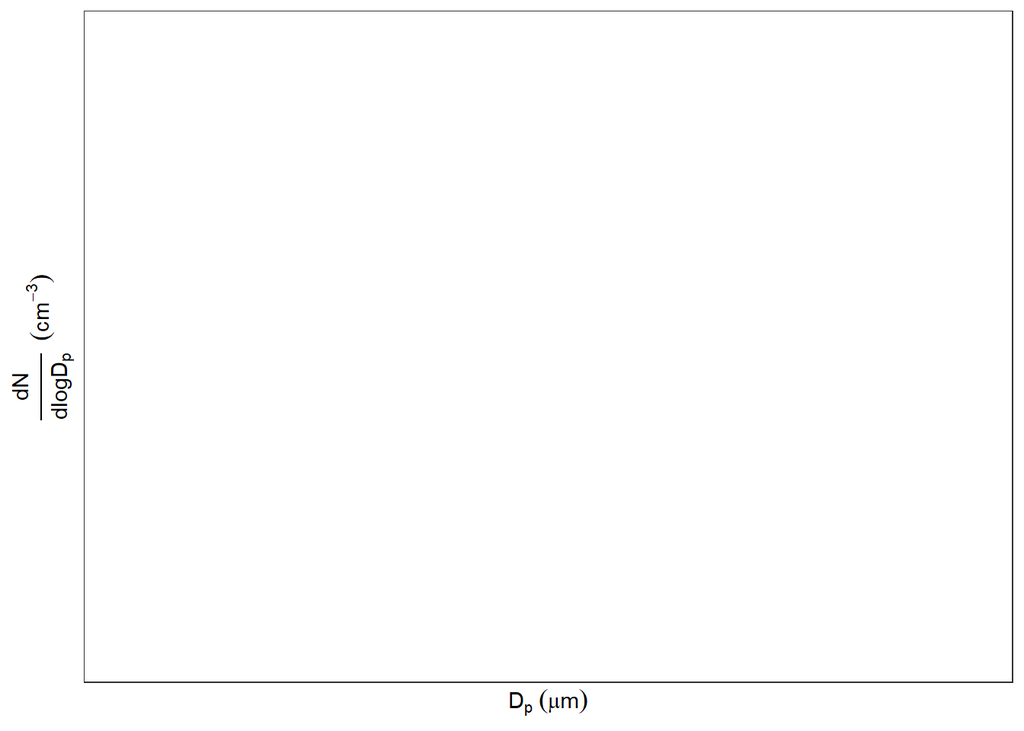

**Figure** 1**.** Aerosol particle size distribution

```r
library(ggplot2)
library(latex2exp)

ggplot() +
    geom_blank() +
    theme_bw() +
    labs(y = TeX(r"($\frac{dN}{d\log D_p}$ $(cm^{-3})$)"),
         x = TeX(r"($D_p$ $(\mu m)$)"))
```

4. How do you generate the following layout for `plot(co2)`?

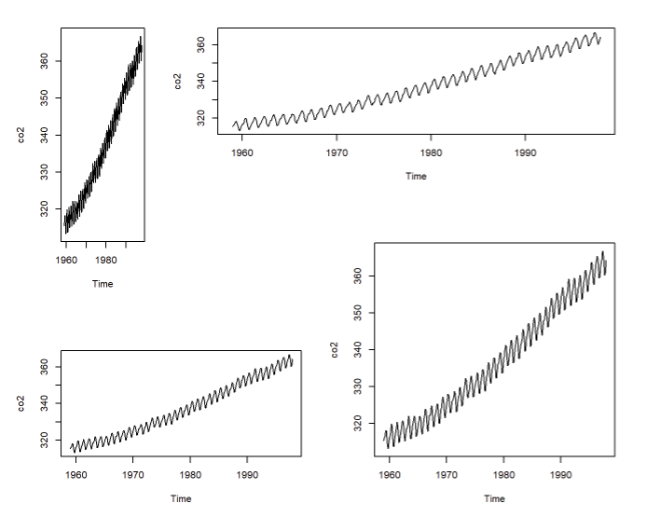

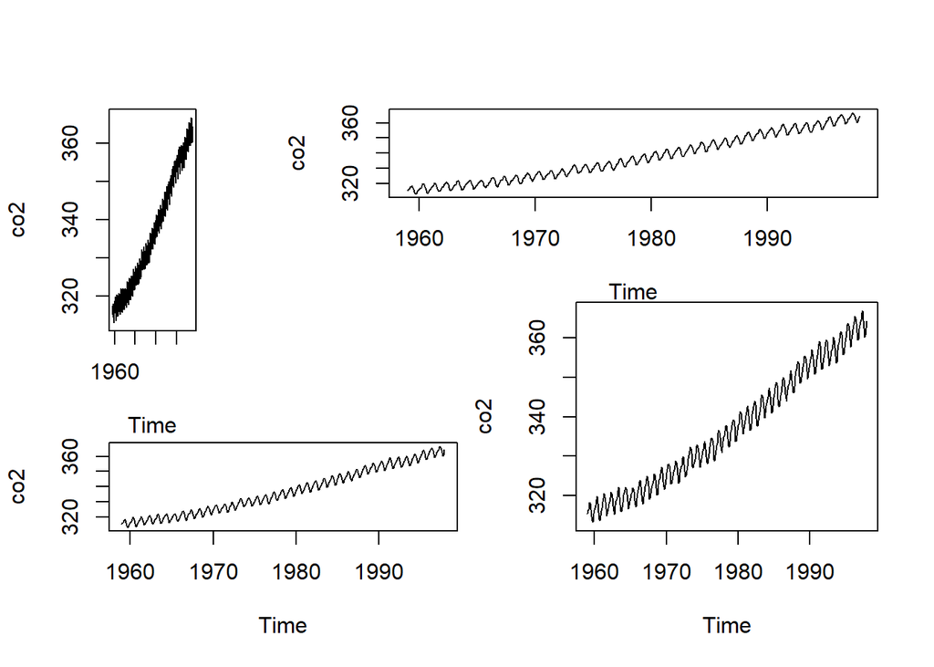

```r
par(fig=c(0,0.27,0.3,1), new=TRUE)
plot(co2)
par(fig=c(0.3, 1, 0.5, 1),new=TRUE)
plot(co2)
par(fig=c(0,0.55,0,0.5), new=TRUE)
plot(co2)
par(fig=c(0.5,1,0,0.71),new=TRUE)
plot(co2)
mtext("", side=4, outer=TRUE, line=-4)
```

5. Insert the graph you created in Exercise 3 into a R markdown document. Give proper numbering and a caption. Cross-refer it in the statement.

Here is the figure Figure 1.